```python
from IPython.display import Image
```

# Naive Bayes Classifiers - Theory

## Naive Bayes Classifiers - Introduction

Naive Bayes Classification is a classification technique based on Bayes' theorem:

- $P(A|B) = \frac{P(B|A)P(A)}{P(B)}$ This is a way for finding the probability of A given B. Recall that this is also applied in **Linear Discriminant Analysis.**

In a Naive Bayes Classifier, we are solving for:

- $P(y|X)=\frac{P(X|y)P(y)}{P(X)}$

where $y$ is the class variable and $X$ is the dependent feature vector

- $X = (x_1,x_2,...,x_n)$

This can be rewritten as:

- $P(y|x_1,...,x_n)=\frac{P(x_1|y)P(x_2|y)...P(x_n|y)P(y)}{P(x_1)P(x_2)...P(x_n)}$

An important assumption in Naive Bayes is that all features are **independent**.

- That means that the presence of a feature in a class is unrelated to the presence of any other features
- E.x. A ball might be classified as a baseball if it is white, 3" in diameter, and round
  - Each feature independently and equally contributes to the probability of that the ball is a baseball
  - We are saying that the ball being white has nothing to do with it being 3" in diameter or round, for example
  - That is why this is known as a "naive" approach

For multiple classes, we are looking for the class variable $y$ that maximizes:

- $y= P(y)\prod_{i=1}^{n}P(x_i|y)$

This can also be expressed as

- $y=argmaxP(y)\prod_{i=1}^{n}P(x_i|y)$

## Example Calculation

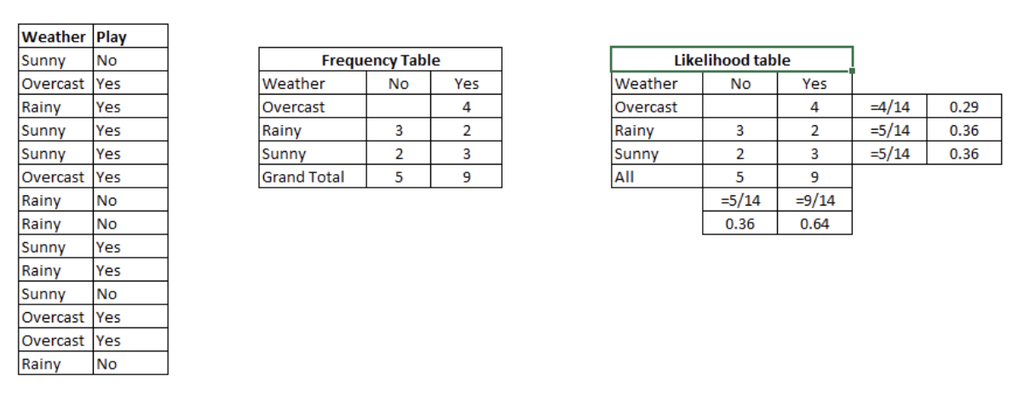

```python
Image('img/naive_bayes_example.png')
```

Source: Analytics Vidhya

In the above example:

- $P(Yes | Sunny) = \frac{P( Sunny | Yes) \cdot P(Yes)}{P (Sunny)}$

Here:

- $P (Sunny |Yes) = \frac{3}{9} = 0.33$
- $P(Sunny) = \frac{5}{14} = 0.36$
- $P(Yes)= \frac{9}{14} = 0.64$

Plug it in:

- $P (Yes | Sunny) = \frac{0.33\cdot0.64}{0.36} = 0.60$
- This has majority probability, so this would be classified as $Yes$

## Types of Naive Bayes Classification

### Gaussian

- Used for classification problems
- Assumes features follow a normal distribution

### Multinomial

- Discrete counts
- E.x. "How often does a word appear in a document"

### Binomial

- Useful if features are binary

## Pros and Cons of Naive Bayes Classification

### Pros

- Easy and fast algorithm
- If the independence assumption holds, then performs better than logistic regression even with less data
- Performs well for categorical input variables
- Particularly useful on text data

### Cons

- Rare for all features to be independent in a dataset
- If a categorical variable appears in the test data but not the training data then the model will never be able to predict it as it will assign the category a zero probability. Resolve using **Laplace Estimation or Smoothing**
- Exact Probabilities that are predicted are not estimated well, although it is enough to make a proper classification

## Laplace Smoothing

We want to eliminate situations where a category is labelled as a zero probability just because it did not appear in the training data. This can especially occur when there are few training instances.

- Consider an example of P(Sneeze = true | Allergy) -- if the value true is always seen, then probability will be 1
- This results in P(Allergy | Sneeze = false) always equalling zero, which is incorrect
- So, we need to smooth out the predictions to eliminate zero probabilities

In a Laplace estimate, pretend that you saw every outcome once more than you did. This guarantees that there are no cases of zero probability.

- $Probability\:of\:class\:y = \frac{(count(y)+1)}{(total\:samples) + 1(number\:of\:possible\:values\:for\:y)}$

This can be extended to saying that you saw every outcome $k$ extra times

- $Probability\:of\:class\:y = \frac{(count(y)+k)}{(total\:samples) + k(number\:of\:possible\:values\:for\:y)}$

## More Resources

[Applying Multinomial Naive Bayes to NLP Problems](https://medium.com/syncedreview/applying-multinomial-naive-bayes-to-nlp-problems-a-practical-explanation-4f5271768ebf)

[Slides on Naive Bayes from UC Berkeley](https://inst.eecs.berkeley.edu/~cs188/sp12/slides/cs188%20lecture%2020%20--%20naive%20bayes%206PP.pdf)